# Homework1

2023-11-01

# Introduction

The objective of this analysis is to clusterize 156 countries / regions with different clustering methods using variables such as their happiness score, life expectancy, perceptions of corruption, etc, and also to analize the relationships between the different variables (which could be used to predict a country’s happiness score as a function of the other variables).

# Data Preprocessing

## Load the data

We load the World Happiness Report dataset.

```r
rm(list=ls()) # delete every data
library(readxl) # this library is for reading Excel files in R
happiness = read_xlsx(path = "World Happiness Report.xlsx")
```

## Libraries

We load all the libraries needed for this project.

```r
library(tidyverse)
library(VIM)
library(Quandl)
library(VIM)
library(lubridate)
library(GGally)
library(factoextra)
library(quantmod)
library(countrycode)
library(rworldmap)
```

```r
library(ggplot2)
library(reshape2)
library(factoextra)
library(cluster)
library(mclust)
```

## NA

We check if there are NA values.

```r
which(is.na(happiness), arr.ind=TRUE)
```

```
##      row col
```

There are no NA values.

## Feature engineering

Since the ranking is dependent on the score, we will remove it.

```r
happiness = happiness[, -c(1)]
```

We create new variables from the happiness dataset that will be used for our analysis.

```r
happiness_numeric = happiness[, -c(1)]
country = happiness[,1]
happiness$`Country or region` = as.factor(happiness$`Country or region`)
```

# Visualization and Descriptive Analysis

We will visualize the data.

Our input has dimension $p=7$, that implies $2^p$ different relations between the variables.

Dimension 1: univariate analysis for the 7 numeric variables.

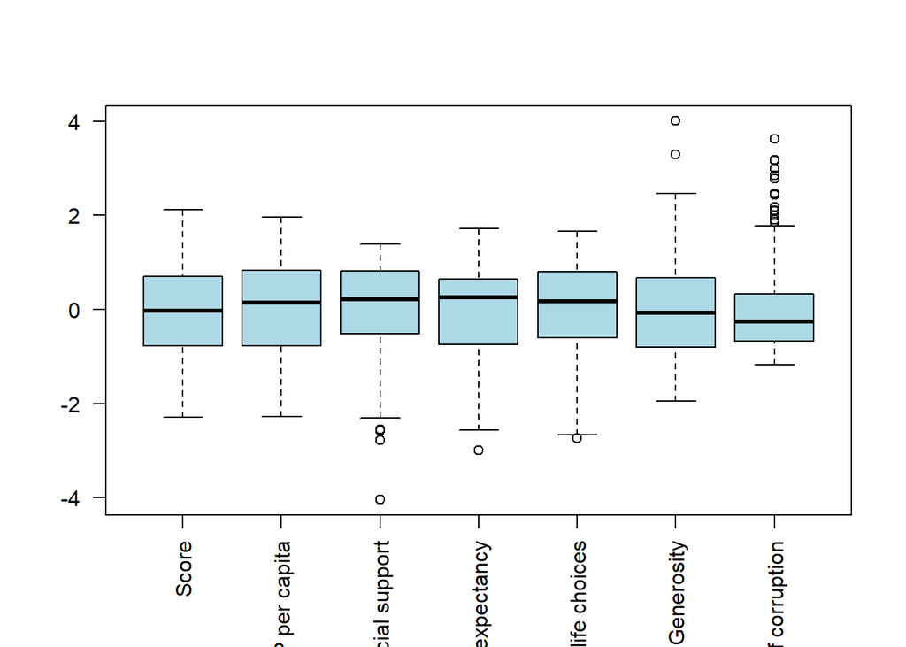

```r
boxplot(scale(happiness_numeric), las=2, col="lightblue")
```

## Outliers

Although in the previous graph we can see that there are outliers, none of them are extreme enough to warrant their removal.

## Correlation

Dimension 2: bivariate analysis (scatter plots).

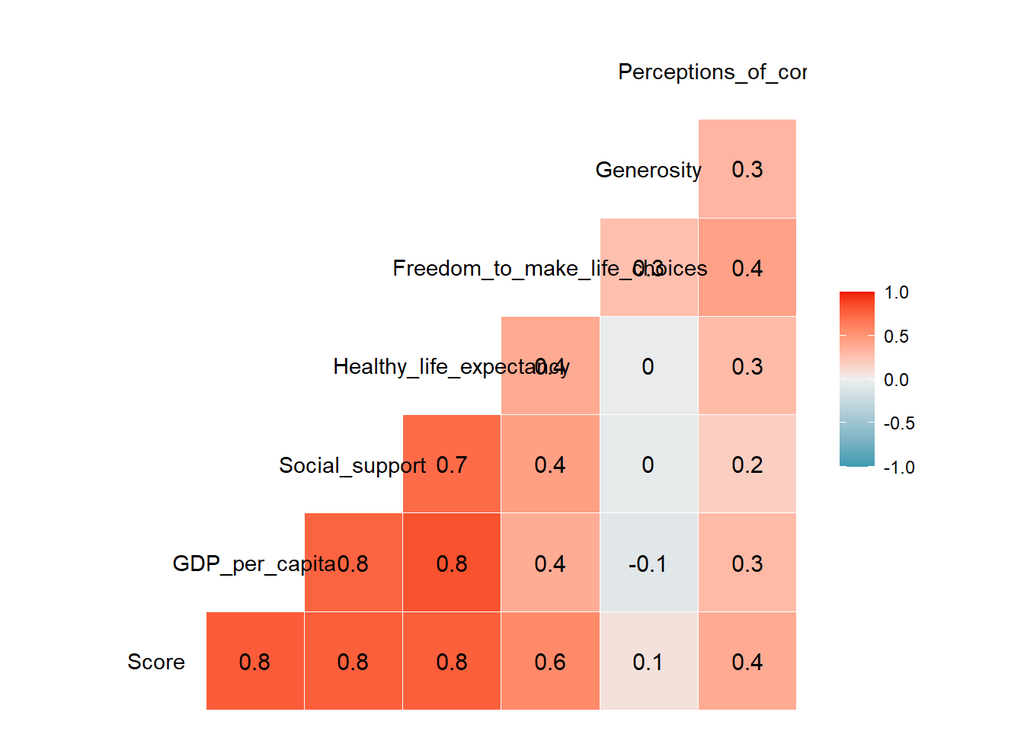

```r
# multiple scatter plot: all relations, 7^2, in dimension 2
ggcorr(happiness_numeric, label = T) # correlation table
```

# PCA

Principal components (PC) are linear combinations of the original variables in a data set that are constructed in such a way that they capture the maximum variance of the data:

$\begin{array}{lll} Y_1 & = & e_{11}X_1 + e_{12}X_2 + \dots + e_{1p}X_p \\ Y_2 & = & e_{21}X_1 + e_{22}X_2 + \dots + e_{2p}X_p \\\end{array}$

```r
pca = prcomp(happiness_numeric, scale=T)
summary(pca)
```

```
## Importance of components:
##                           PC1    PC2     PC3     PC4     PC5     PC6     PC7
## Standard deviation     1.9526 1.1946 0.78287 0.74586 0.51196 0.41510 0.39587
## Proportion of Variance 0.5446 0.2039 0.08756 0.07947 0.03744 0.02462 0.02239
## Cumulative Proportion  0.5446 0.7485 0.83608 0.91555 0.95300 0.97761 1.00000
```

## How many components?

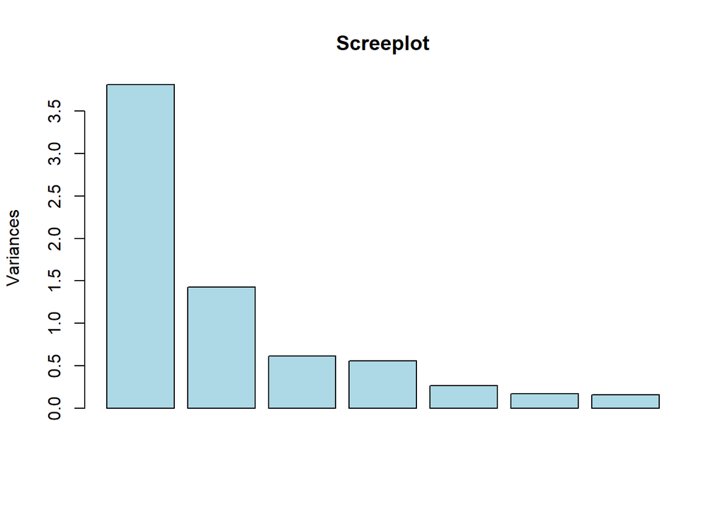

```r
screeplot(pca,main="Screeplot",col="lightblue",type="barplot",pch=19)
```

Nicer with the factoextra package:

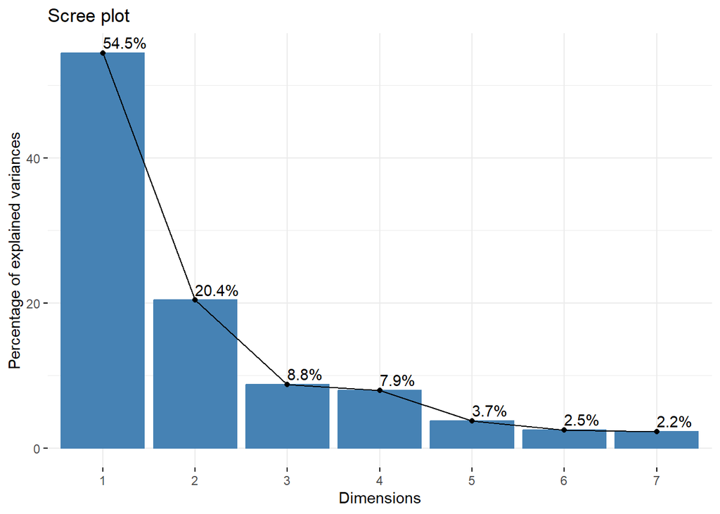

```r
fviz_screeplot(pca, addlabels = TRUE)
```

Since we have 7 variables, on average each variable should account for around 14.3% of the contributions to a given dimension.

## Interpretation of the components

### First component:

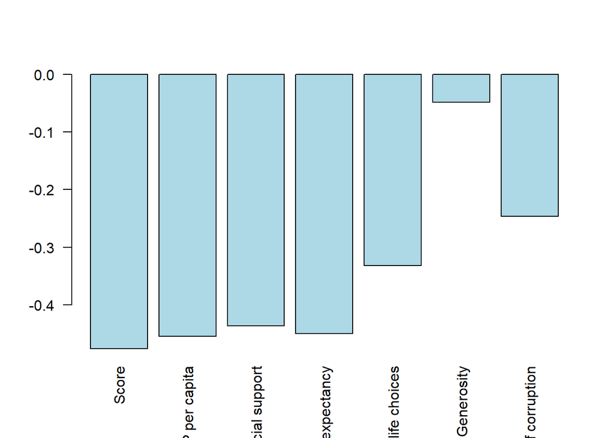

```r
barplot(pca$rotation[,1], las=2, col="lightblue")
```

The sum of the squared loadings (eigenvectors) of a PCA component should always be one:

```r
sum(pca$rotation[,1]^2)
```

```
## [1] 1
```

Plot of the squared values:

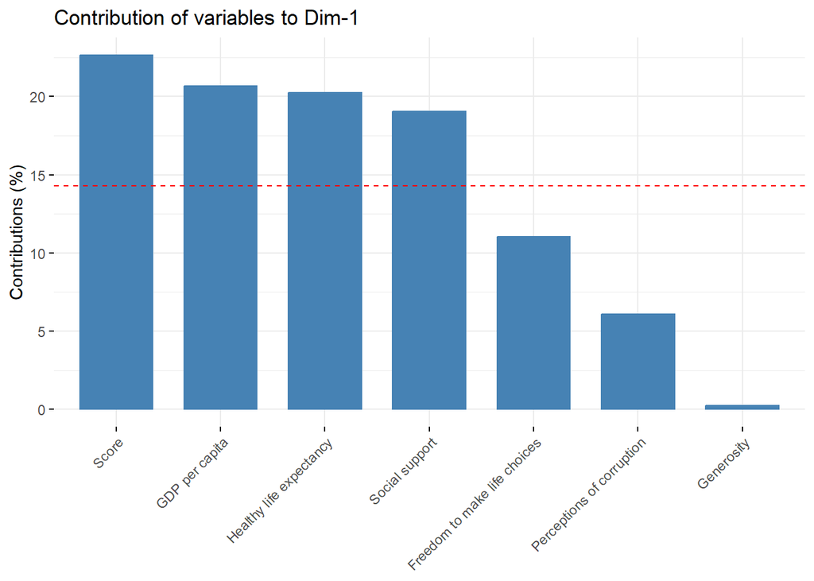

```r
fviz_contrib(pca, choice = "var", axes = 1)
```

As we can see, the score is a very important variable in dimension 1, meaning that it is a very important dimension for what we are trying to achieve: predicting the score from the rest of the variables. Even though all of the variables are inversely correlated with dimension 1, the perceptions of corruption and especially the generosity have very little effect on it.

### Second component:

Loadings:

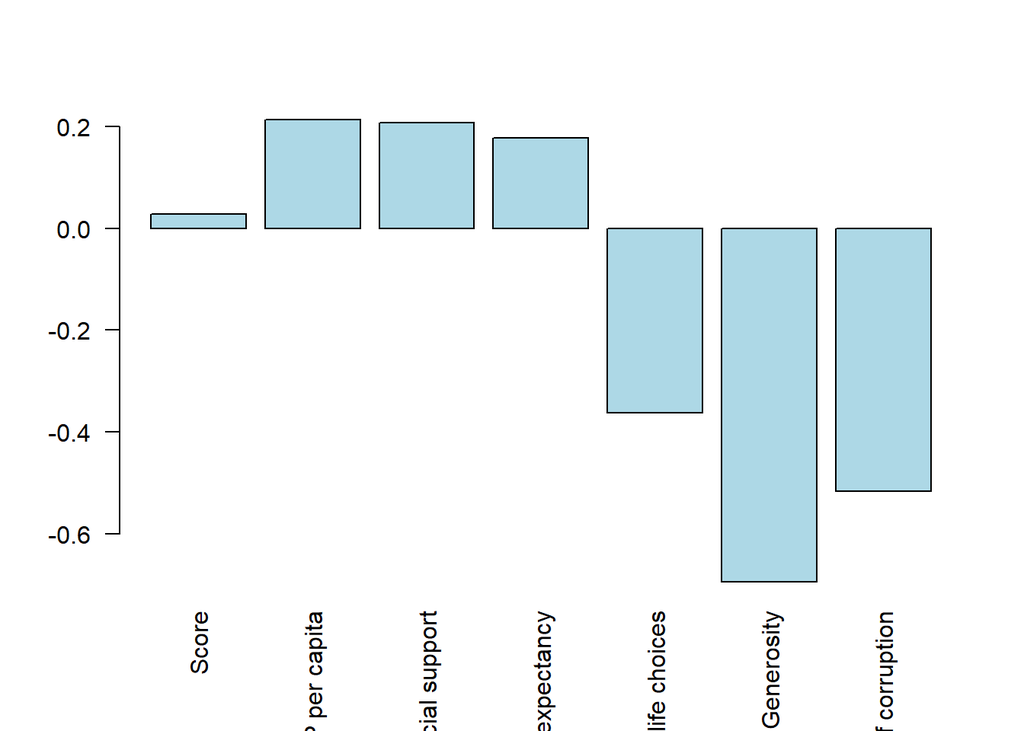

```r
barplot(pca$rotation[,2], las=2, col="lightblue")
```

Plot of the squared values:

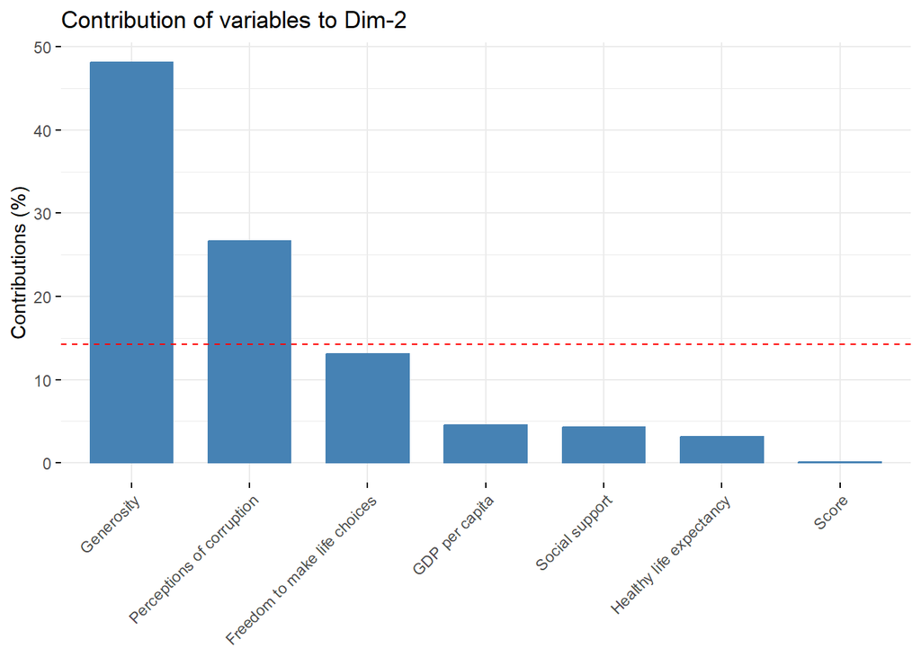

```r
fviz_contrib(pca, choice = "var", axes = 2)
```

Fittingly, the variables that impact dimension 2 are almost the exact opposite from those which impact dimension 1. The score is almost meaningless, while almost half of the contributions to dimension 2 are from the generosity variable.

### Third component:

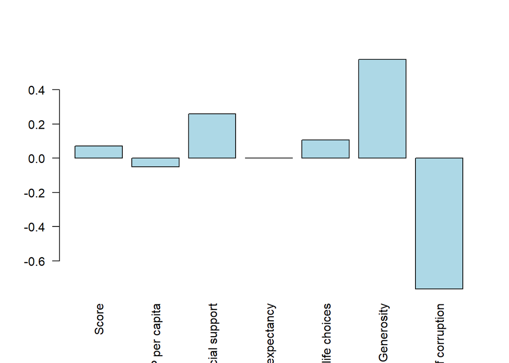

```r
barplot(pca$rotation[,3], las=2, col="lightblue")
```

Plot of the squared values:

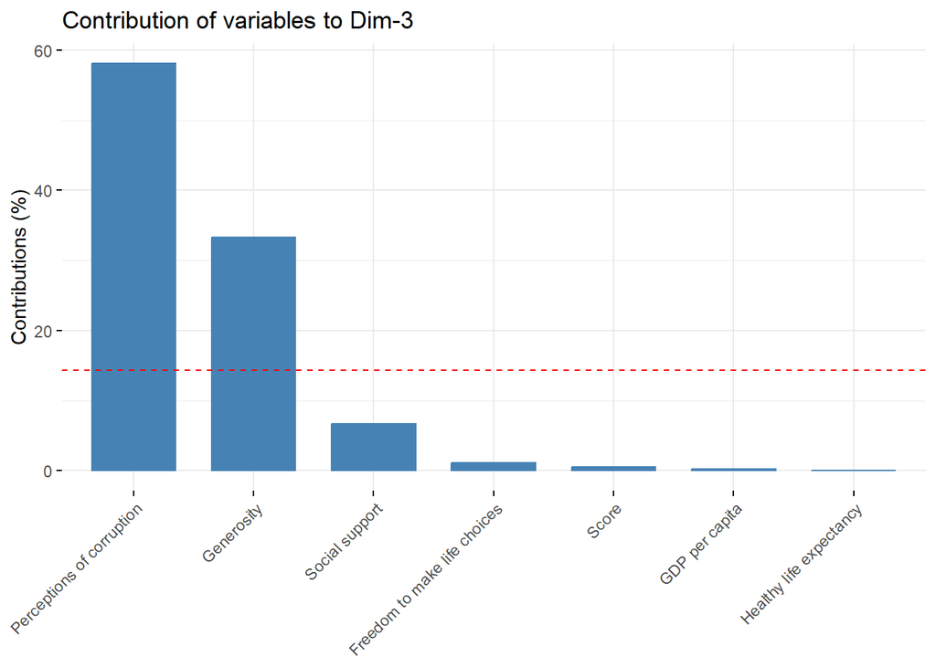

```r
fviz_contrib(pca, choice = "var", axes = 3)
```

Dimension 3 is somewhat similar to dimension 2 in that variables such as perceptions of corruption and generosity contribute the most and the score is almost irrelevant, but in this case it is even more extreme since the perceptions of corruption makes up more than half of the contributions to dimension 3.

## Biplot

We represent a biplot with the observations and the variables in the same graph (using the first 2 components):

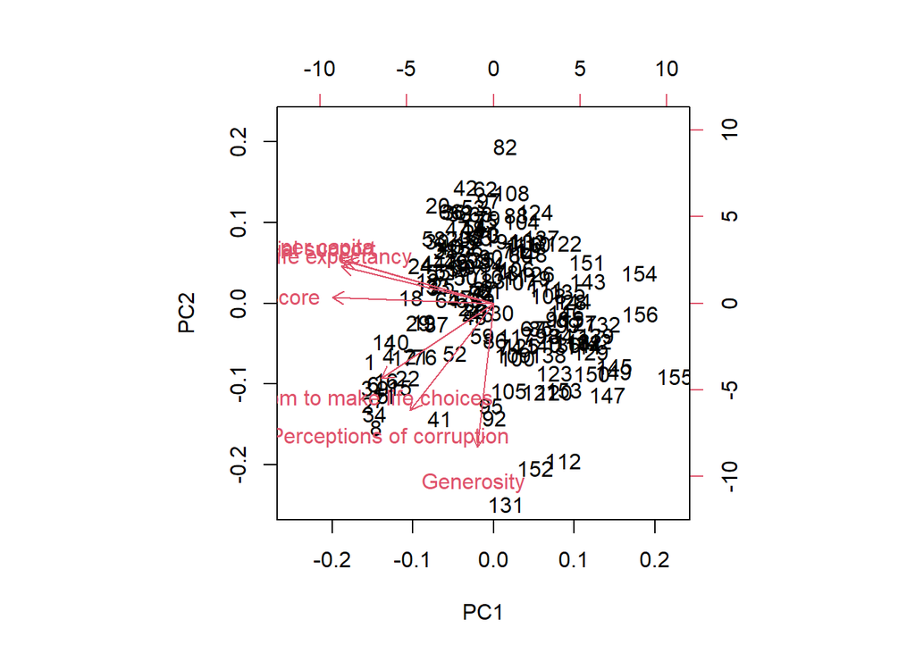

```r
biplot(pca)
```

In this case, it is not informative, since there is a saturation of information.

A nicer plot that uses contributions instead of loadings:

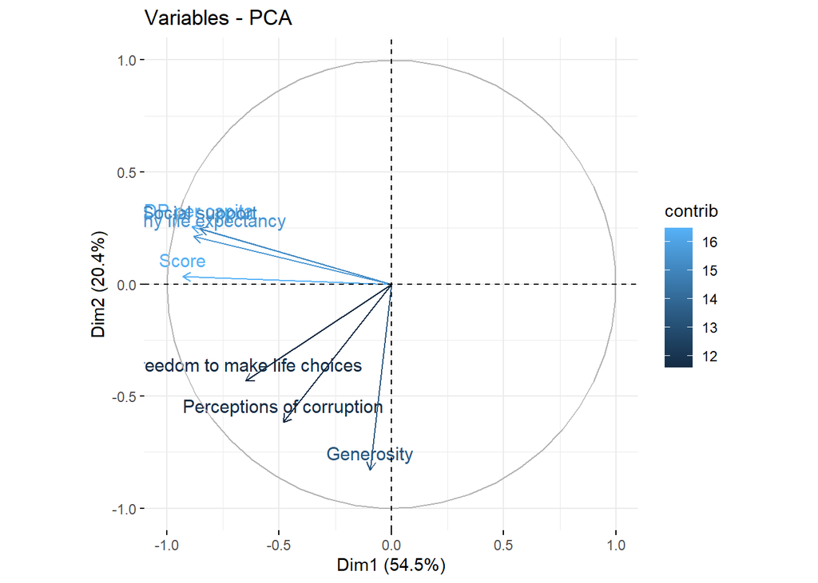

```r
fviz_pca_var(pca, col.var = "contrib")
```

# Factor Analysis

Factor analysis is an analytical tool (model) to reduce the dimension, from $m$ to $r$ factors.

Model with $r$ factors: for each maturity $m$, $x_{m,t} = \mu_m + L_{m}*f_{t} + a_{m,t}$

The estimation of the model (L and cov(a)) is based on the decomposition of cov(x):
$$\text{cov}(x) =
L*L' + \text{cov}(a)$$

Let’s fit a 3-factor model with no rotation

```r
happiness.f <- factanal(happiness_numeric, factors = 3, rotation="none", scores="regression")
cbind(happiness.f$loadings, happiness.f$uniquenesses)
```

```
##                                  Factor1     Factor2      Factor3
## Score                        0.906800279  0.13370526  0.114757695 0.1466700
## GDP per capita               0.919328990 -0.15430994 -0.143361413 0.1104711
## Social support               0.840255317 -0.09431782  0.243823137 0.2256267
## Healthy life expectancy      0.878894869 -0.09295766 -0.091337117 0.2105695
## Freedom to make life choices 0.525944381  0.50219625  0.206198996 0.4286669
## Generosity                   0.006994068  0.53239730 -0.008657277 0.7164429
## Perceptions of corruption    0.375081769  0.60588809 -0.311853776 0.3949607
```

## Interpretation

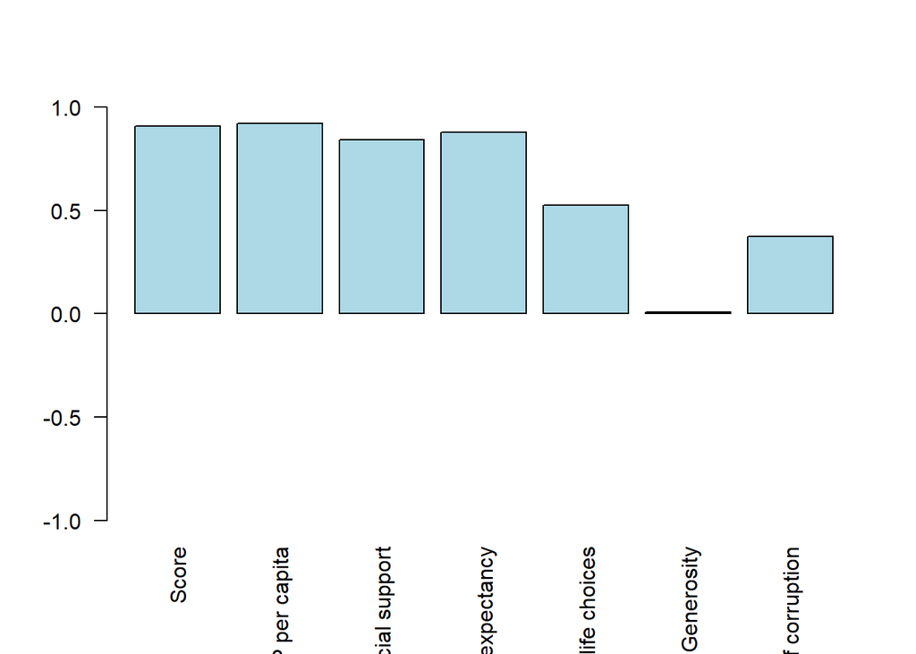

```r
barplot(happiness.f$loadings[,1], las=2, col="lightblue", ylim = c(-1, 1))
```

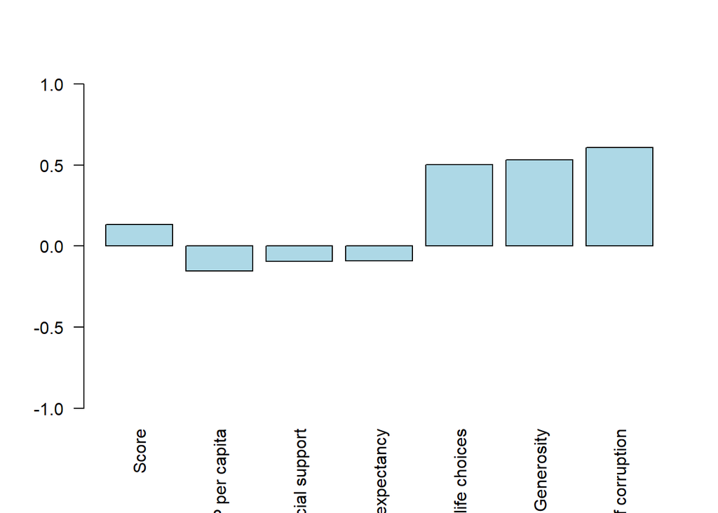

```r
barplot(happiness.f$loadings[,2], las=2, col="lightblue", ylim = c(-1, 1))
```

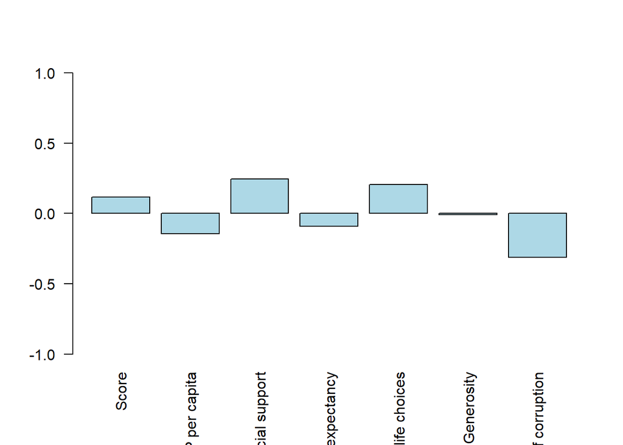

```r
barplot(happiness.f$loadings[,3], las=2, col="lightblue", ylim = c(-1, 1))
```

## Prediction model

```r
happiness.f <- factanal(happiness_numeric[,-1], factors = 3, rotation="varimax")
```

For the prediction model, we want to be able to predict the Score variable as a function of the other six variables. To do that, we do a factor analysis of the six variables using three factors and the varimax rotation (which makes the prediction process more simple). Afterwards, we could make a linear regression model using lm() for example and input values of the six independent variables to obtain the dependent variable which is happiness.

# Clustering

## Initial guess

We initially assume that there are five clusters (an equal number to the number of continents).

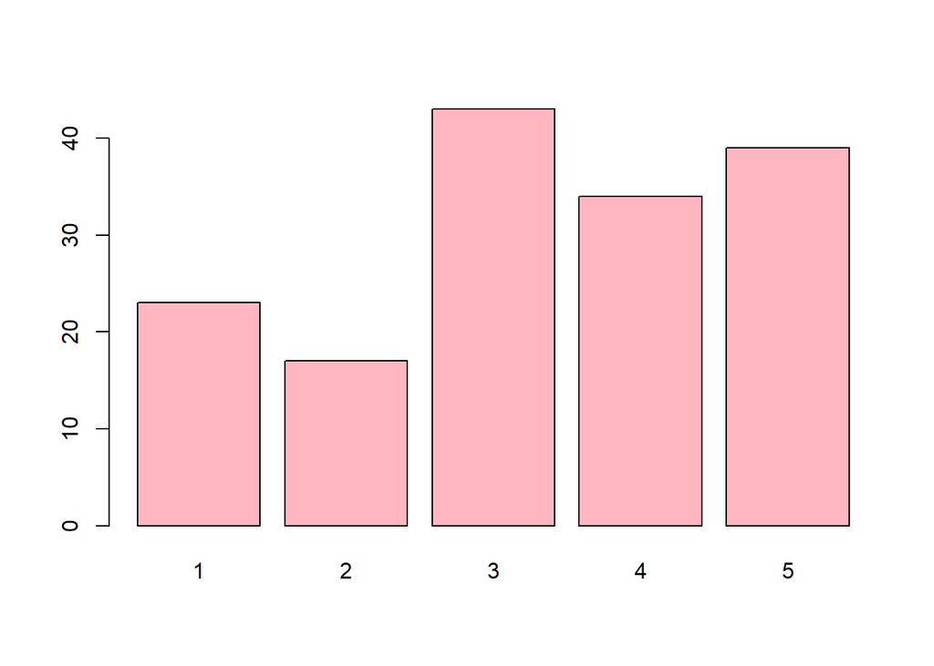

```r
fit = kmeans(scale(happiness_numeric), centers=5, nstart=1000)
groups = fit$cluster
barplot(table(groups), col="lightpink")
```

## Plot using our initial guess

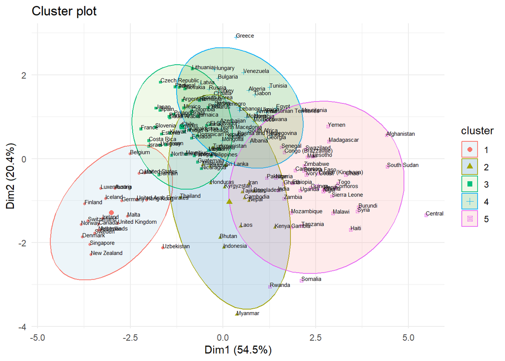

```r
fviz_cluster(fit, data = happiness_numeric, geom = c("point"),
            ellipse.type = 'norm', pointsize = 1) + theme_minimal() +
            geom_text(label = country$`Country or region`, hjust = 0, vjust = 0,
            size = 2,check_overlap = F) + scale_fill_brewer(palette = "Paired")
```

## K-means

To find out the optimal number of clusters for k-means, we can get some hints from silhouette, wss, and GAP.

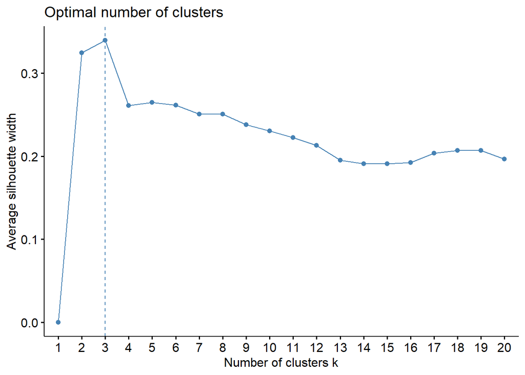

```r
fviz_nbclust(scale(happiness_numeric), kmeans, method = 'silhouette', k.max = 20, nstart = 1000)
```

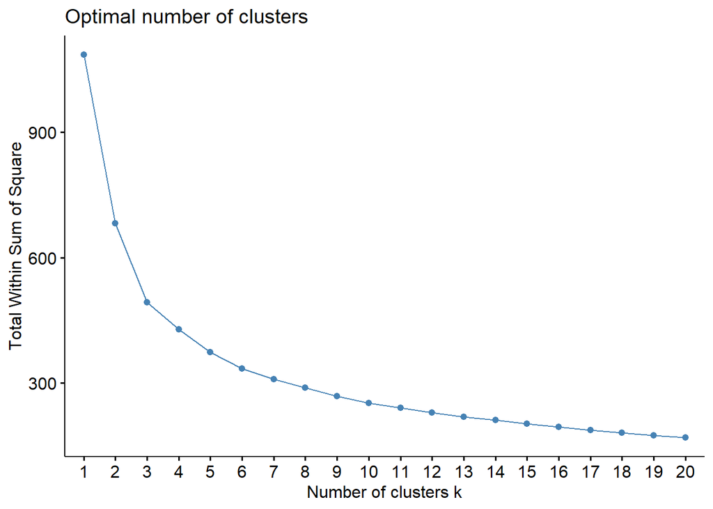

```r
fviz_nbclust(scale(happiness_numeric), kmeans, method = 'wss', k.max = 20, nstart = 1000)
```

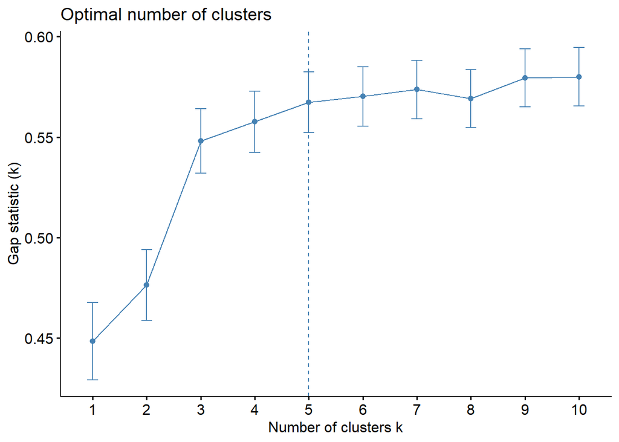

```r
fviz_nbclust(scale(happiness_numeric), kmeans, method = 'gap_stat', k.max = 10, nstart = 100, nboot = 500)
```

Since the silhouette and GAP methods give us different answers and the wss method is ambiguous, we will try other methods apart from k-means which give us an optimal number of clusters which is less ambiguous.

## PAM

PAM is a clustering method which works by partitioning (clustering) the data into k clusters *around medoids*. It is a more robust version than k-means since the centers are now countries.

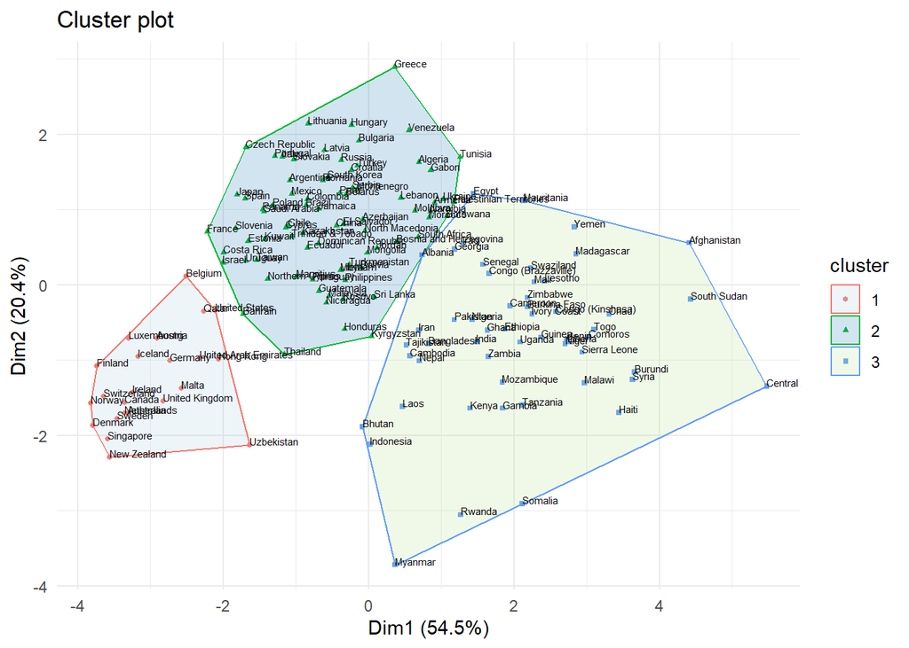

```r
fit.pam <- eclust(happiness_numeric, "pam", stand=TRUE, k=3, graph=F)
fviz_cluster(fit.pam, data = happiness_numeric, geom = c("point"), pointsize = 1) +
            theme_minimal() + geom_text(label = country$`Country or region`,
            hjust = 0, vjust = 0, size = 2, check_overlap = F) +
            scale_fill_brewer(palette = "Paired")
```

Number of clusters with PAM:

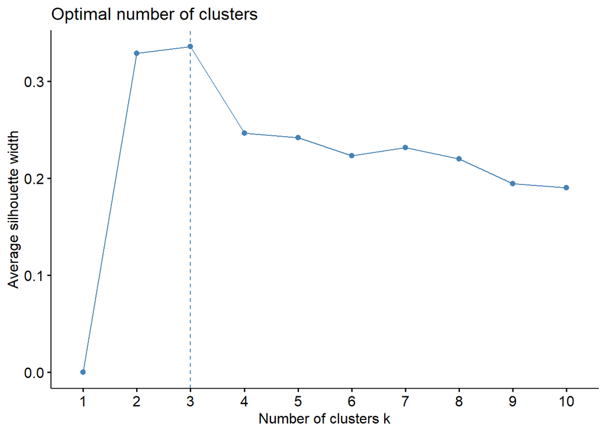

```r
fviz_nbclust(scale(happiness_numeric), pam, method = 'silhouette', k.max = 10)
```

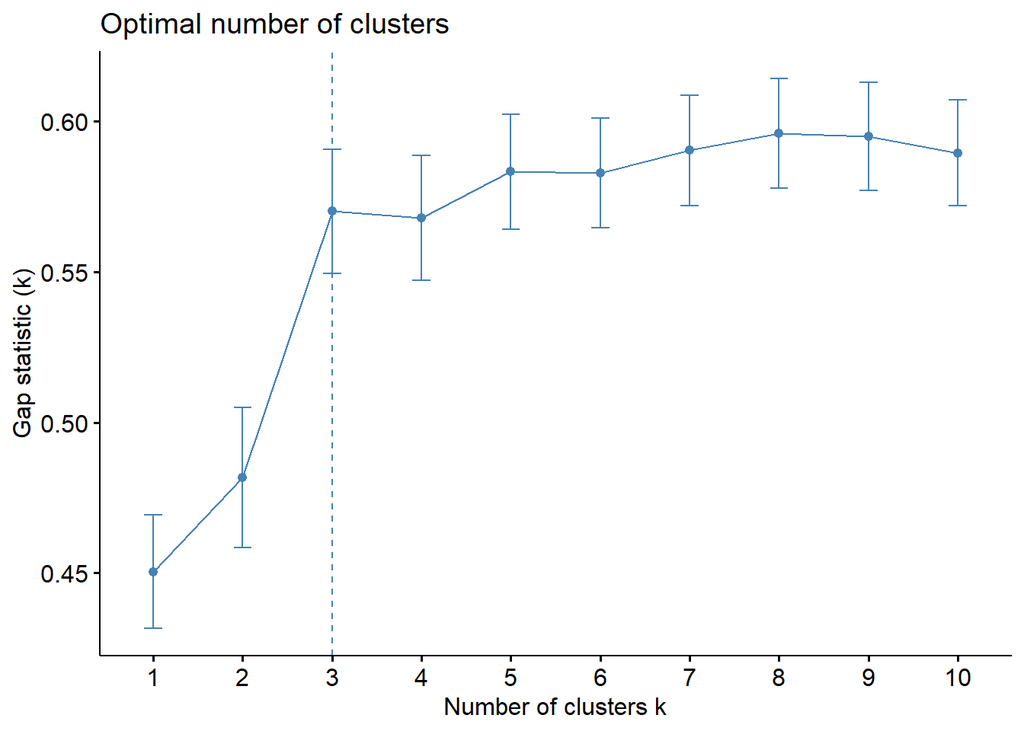

```r
fviz_nbclust(scale(happiness_numeric), pam, method = 'gap_stat', k.max = 10, nboot = 500)
```

From what we can see, when using PAM, three clusters are more optimal than the five that we initially assumed were best. To close the question once and for all, we will try one last clustering method to find the optimum number of clusters.

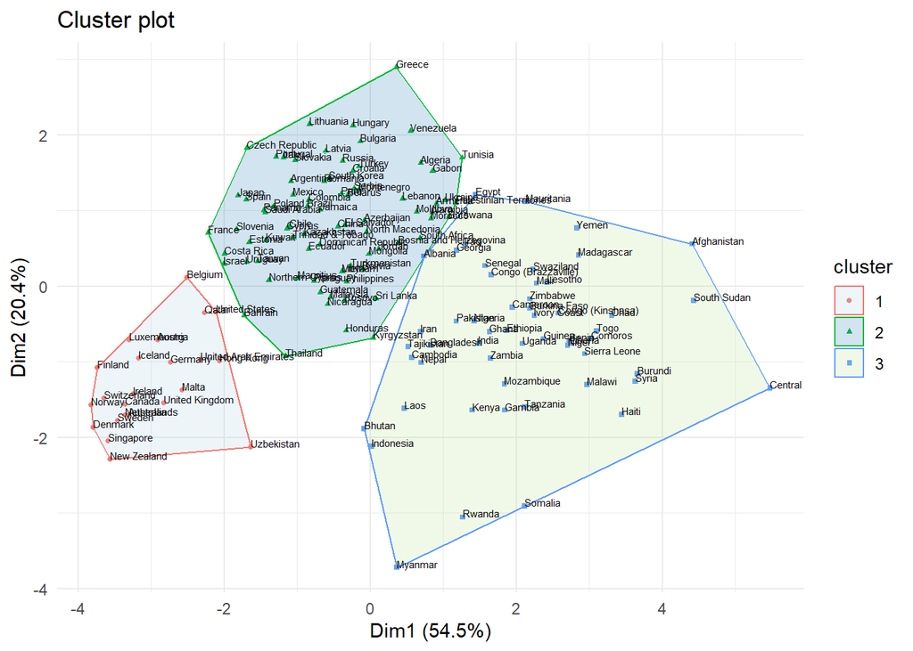

```r
fviz_cluster(fit.pam, data = happiness_numeric, geom = c("point"), pointsize = 1) +
            theme_minimal() + geom_text(label = country$`Country or region`,
            hjust = 0, vjust=0,size=2,check_overlap = F) +
            scale_fill_brewer(palette="Paired")
```

### Map of the PAM clustering

```r
map = data.frame(country = country$`Country or region`, value = fit.pam$clustering)
map$country = countrycode(map$country, 'country.name', 'iso3c')
matched <- joinCountryData2Map(map, joinCode = "ISO3",
                               nameJoinColumn = "country")
```

```
## 155 codes from your data successfully matched countries in the map
## 1 codes from your data failed to match with a country code in the map
## 89 codes from the map weren't represented in your data
```

```
## You asked for 7 categories, 4 were used due to pretty() classification
```

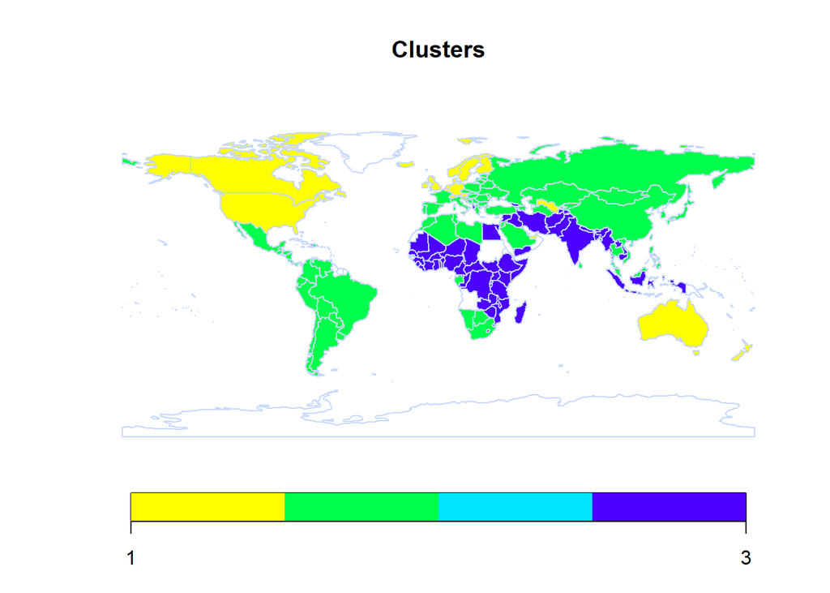

```r
mapCountryData(matched, nameColumnToPlot="value", missingCountryCol = "white",
               borderCol = "#C7D9FF", catMethod = "pretty", colourPalette = "topo",                mapTitle = c("Clusters"), lwd=1)
```

## EM clustering

Expectation-Maximization clustering is like k-means but it computes the probabilities of cluster memberships based on probability distributions. Hence, the goal of the EM clustering then is to maximize the overall likelihood of the data, given the (final) clusters.

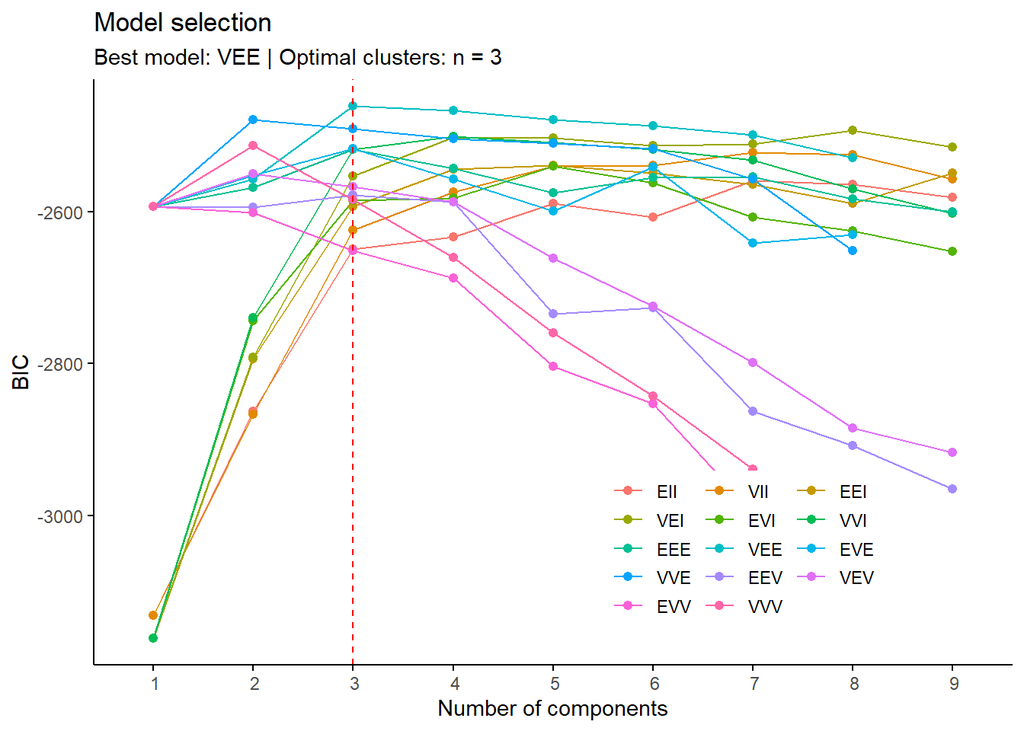

```r
res.Mclust <- Mclust(scale(happiness_numeric))
fviz_mclust(object = res.Mclust, what = "BIC", pallete = "jco") + scale_x_discrete(limits = c(1:10))
```

Therefore, given that in both PAM and EM clustering the optimal number of clusters is three, we will use three clusters in our hierarchical clustering and in our interpretation of the cluster centers.

## Map of the EM clustering

```r
groups.mclust = res.Mclust$classification
map = data.frame(country = country$`Country or region`, value = groups.mclust)
map$country = countrycode(map$country, 'country.name', 'iso3c')
matched <- joinCountryData2Map(map, joinCode = "ISO3",
                               nameJoinColumn = "country")
```

```
## 155 codes from your data successfully matched countries in the map
## 1 codes from your data failed to match with a country code in the map
## 89 codes from the map weren't represented in your data
```

```
## You asked for 7 categories, 4 were used due to pretty() classification
```

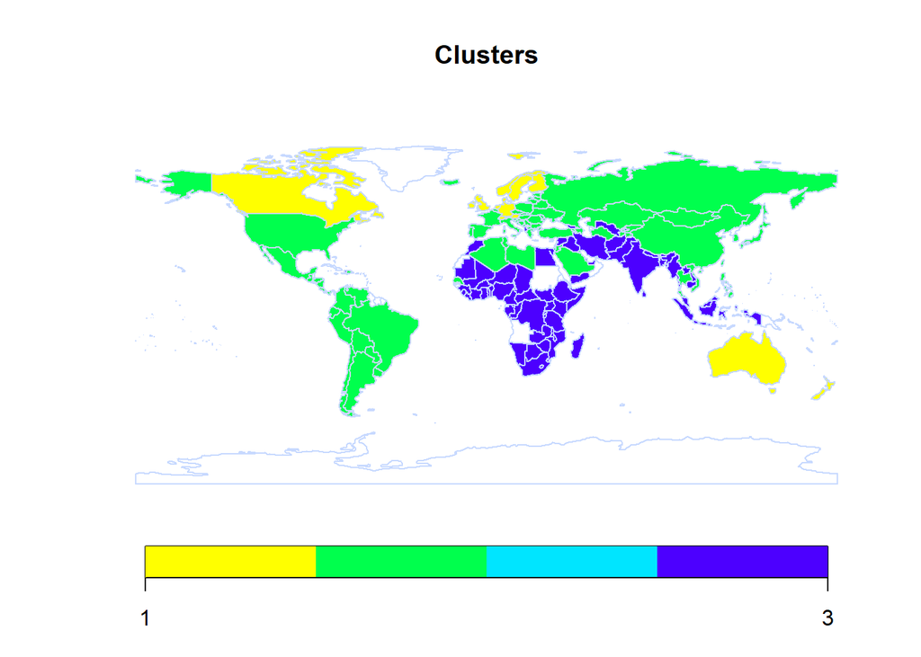

```r
mapCountryData(matched,nameColumnToPlot = "value", missingCountryCol = "white",
               borderCol = "#C7D9FF", catMethod = "pretty", colourPalette = "topo",                mapTitle = c("Clusters"), lwd=1)
```

As we can see from the two maps, the PAM and EM clusterizations are very similar, with some differences with countries such as the US, South Africa, etc.

## Hierarchical clustering

It is important to decide the distance between the observations and the linkage to join groups.

```r
d = dist(scale(happiness_numeric), method = "euclidean")
hc <- hclust(d, method = "ward.D2")
```

### Visualization of hierarchical clustering

Classical dendrogram:

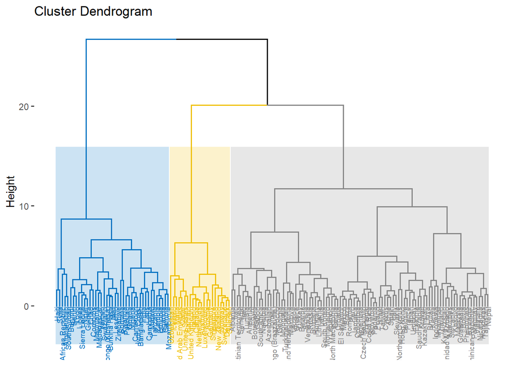

```r
hc$labels <- country$`Country or region`
fviz_dend(x = hc, k = 3, palette = "jco", rect = TRUE,rect_fill = TRUE, cex=0.5,
          rect_border = "jco")
```

Since it is difficult to visualize the countries, we will use a phylogenic tree:

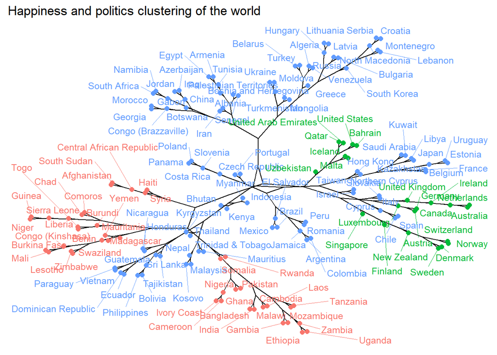

```r
fviz_dend(x = hc, k = 3, color_labels_by_k = TRUE, cex = 0.8, type = "phylogenic",
          repel = TRUE) +
          labs(title="Happiness and politics clustering of the world") +
          theme(axis.text.x=element_blank(),axis.text.y=element_blank())
```

### Map of the hierarchical clustering

```r
groups.hc = cutree(hc, k = 3)

map = data.frame(country = country$`Country or region`, value = groups.hc)
map$country = countrycode(map$country, 'country.name', 'iso3c')
matched <- joinCountryData2Map(map, joinCode = "ISO3",
                               nameJoinColumn = "country")
```

```
## 155 codes from your data successfully matched countries in the map
## 1 codes from your data failed to match with a country code in the map
## 89 codes from the map weren't represented in your data
```

```
## You asked for 7 categories, 4 were used due to pretty() classification
```

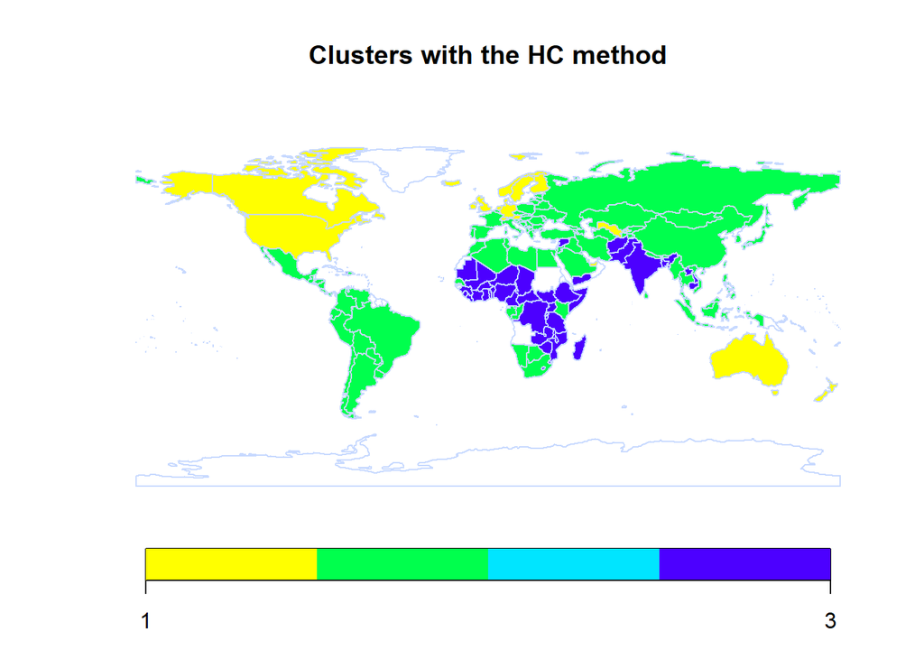

```r
mapCountryData(matched,nameColumnToPlot="value",missingCountryCol = "white",
               borderCol = "#C7D9FF", catMethod = "pretty", colourPalette = "topo",                mapTitle = c("Clusters with the HC method"), lwd=1)
```

This map looks very similar to the two previous maps from PAM and EM clustering.